# warnings_analysis

Andrew Ba Tran

July 15, 2015

An [analysis](http://trendct.github.io/ct-tickets/warnings_analysis.html) for the TrendCT story: [Who gets off with a warning after a traffic stop in Connecticut?](http://trendct.org/2015/07/16/who-gets-off-with-a-warning-after-a-traffic-stop-in-connecticut)

The data is from the [Connecticut Racial Profiling Prohibition Project](http://ctrp3.ctdata.org/rawdata/) hosted at the [CT Data Collaborative](http://ctdata.org/) which collects traffic incident reports between October 2013 and September 2014.

```r
library(lubridate)
library(ggplot2)
library(dplyr)
library(DT)
library(knitr)
library(stringr)
library(tidyr)
incidents <- read.csv("http://ctrp3viz.s3.amazonaws.com/data/Connecticut_r1.csv", stringsAsFactors=FALSE)

#warnings <- incidents[grepl("Warn",incidents$InterventionDispositionReasonText),]
```

**Observations**

- There were 595951 traffic stops in this data set

## OK, let’s take a look at departments and tickets vs warnings

```r
incidents$InterventionDispositionCode <- str_trim(incidents$InterventionDispositionCode)

# Graph 1. Tickets versus warnings
index <- c("I", "M", "N", "U", "V", "W")

values <- c("Ticket", "Ticket", "Ticket", "Ticket", "Warning", "Warning")

# for all
incidents$What <- values[match(incidents$InterventionDispositionCode, index)]

violations <- data.frame(table(incidents$StatutoryReasonForStop, incidents$What))
colnames(violations) <- c("violation", "type", "freq")
violations_df <- violations %>% spread(type, freq)
violations_df$perc_ticket <- round((violations_df$Ticket/(violations_df$Ticket+violations_df$Warning))*100, digits=2)
violations_df$perc_warning <- round((violations_df$Warning/(violations_df$Ticket+violations_df$Warning))*100, digits=2)
datatable(violations_df)
```

|  | violation | Ticket | Warning | perc_ticket | perc_warning |
| --- | --- | --- | --- | --- | --- |
| 1 | Cell Phone | 35785 | 17797 | 66.79 | 33.21 |
| 2 | Defective Lights | 8102 | 45124 | 15.22 | 84.78 |
| 3 | Display of Plates | 4983 | 12515 | 28.48 | 71.52 |
| 4 | Equipment Violation | 619 | 1444 | 30 | 70 |
| 5 | Moving Violation | 19537 | 25375 | 43.5 | 56.5 |
| 6 | Other | 72255 | 23454 | 75.49 | 24.51 |
| 7 | Registration | 43540 | 12177 | 78.14 | 21.86 |
| 8 | Seatbelt | 18464 | 5911 | 75.75 | 24.25 |
| 9 | Speed Related | 91372 | 69249 | 56.89 | 43.11 |
| 10 | Stop Sign | 11821 | 22496 | 34.45 | 65.55 |

[output cut: 4 more lines]

**Observations**

- Police were more lenient on drivers who were pulled over for defective lights, display of plates, and equipment violations.
- Police were most harsh on drivers pulled over for a suspended license.
- Only 9 percent of those pulled over for suspended license got away with a warning
- Driving without registration, without wearing a seatbelt or while using a cell phone also lead to many more tickets than warnings.

## Stats on each department that gave out warnings

```r
warnings <- data.frame(table(incidents$Department.Name, incidents$InterventionDispositionCode))
colnames(warnings) <- c("Department", "Disposition", "Freq")
warnings_df <- warnings %>% spread(Disposition, Freq)
warnings_df$total <- warnings_df$I + warnings_df$M + warnings_df$N + warnings_df$U + warnings_df$V + warnings_df$W
warnings_df$warnings <- warnings_df$V + warnings_df$W
warnings_df$tickets <- warnings_df$total - warnings_df$warnings

warnings_df$perc_warnings <- round((warnings_df$warnings/warnings_df$total)*100, digits=2)
warnings_df$perc_tickets <- 100 - warnings_df$perc_warnings
warnings_df_table <- warnings_df[c("Department", "total", "tickets", "warnings", "perc_tickets", "perc_warnings")]
write.csv(warnings_df_table, "department_warnings.csv")
datatable(warnings_df_table)
```

|  | Department | total | tickets | warnings | perc_tickets | perc_warnings |
| --- | --- | --- | --- | --- | --- | --- |
| 1 | Ansonia | 4883 | 1940 | 2943 | 39.73 | 60.27 |
| 2 | Avon | 667 | 202 | 465 | 30.28 | 69.72 |
| 3 | Berlin | 6644 | 2840 | 3804 | 42.75 | 57.25 |
| 4 | Bethel | 3712 | 1149 | 2563 | 30.95 | 69.05 |
| 5 | Bloomfield | 5515 | 1992 | 3523 | 36.12 | 63.88 |
| 6 | Branford | 6891 | 4779 | 2112 | 69.35 | 30.65 |
| 7 | Bridgeport | 4717 | 3158 | 1559 | 66.95 | 33.05 |
| 8 | Bristol | 4653 | 2157 | 2496 | 46.36 | 53.64 |
| 9 | Brookfield | 3223 | 893 | 2330 | 27.71 | 72.29 |
| 10 | Canton | 1751 | 429 | 1322 | 24.5 | 75.5 |

[output cut: 94 more lines]

**Observations**

## Interesting. Ok let’s look at age

```r
# by age
incidents_all <- incidents
incidents$SubjectAge <- as.numeric(incidents$SubjectAge)
```

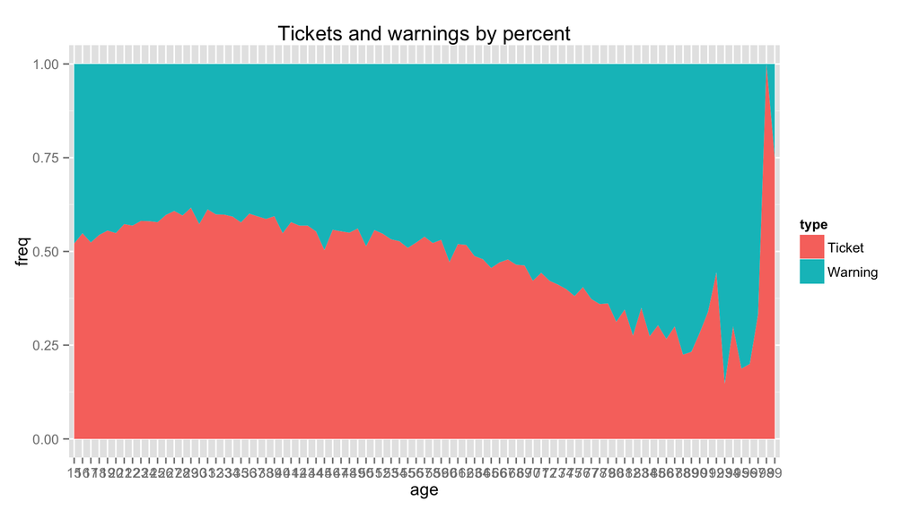

```r
# We have to take out the outlier ages, first. There are some weird negative ages and such

incidents <- subset(incidents, SubjectAge > 14 & SubjectAge < 100)

incidents_age <- data.frame(table(incidents$SubjectAge,incidents$What))
colnames(incidents_age) <- c("age", "type", "freq")

incidents_age_df <- incidents_age %>% spread(type, freq)
incidents_age_df$perc_ticket <- round((incidents_age_df$Ticket/(incidents_age_df$Ticket+incidents_age_df$Warning))*100, digits=2)
incidents_age_df$perc_warning <- round((incidents_age_df$Warning/(incidents_age_df$Ticket+incidents_age_df$Warning))*100, digits=2)

warnings_only <- subset(incidents, What=="Warning")
tickets_only <- subset(incidents, What=="Ticket")

ggplot(incidents_age, aes(age, freq, group=type, fill=type)) + ggtitle("Tickets and warnings by percent") + geom_area(position="fill")
```

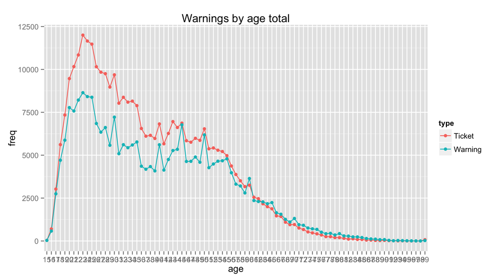

```r
ggplot(incidents_age, aes(age, y=freq, group=type, colour=type)) +
  ggtitle("Warnings by age total") +
  geom_line() +
  geom_point()
```

## Does age change between men and women for warnings?

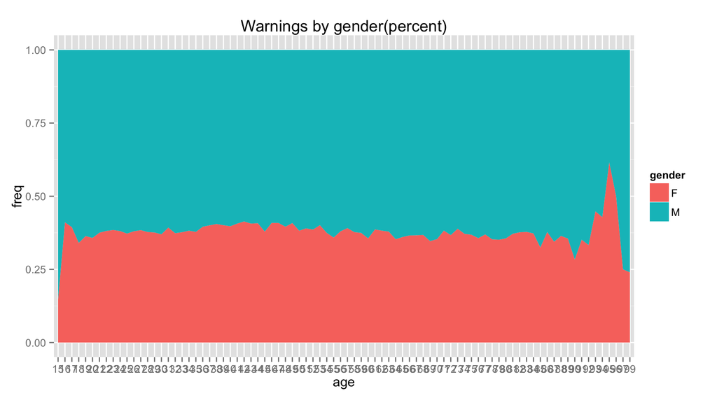

```r
warnings_gender <- data.frame(table(warnings_only$SubjectAge,warnings_only$SubjectSexCode))
colnames(warnings_gender) <- c("age", "gender", "freq")

ggplot(warnings_gender, aes(age, freq, group=gender, fill=gender)) + ggtitle("Warnings by gender(percent)") + geom_area(position="fill")
```

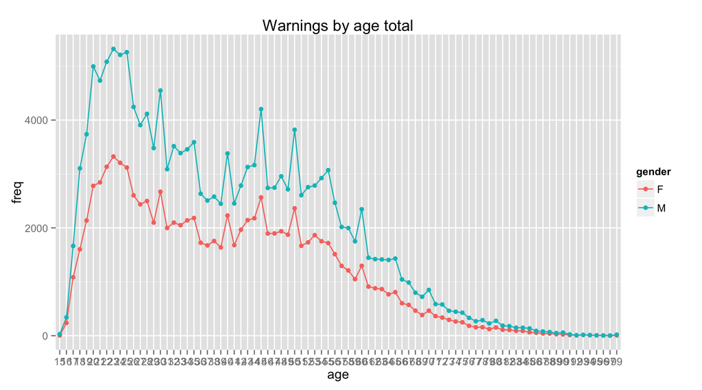

```r
warnings_gender_df <- warnings_gender %>% spread(gender, freq)
warnings_gender_df$perc_male <- round((warnings_gender_df$M/(warnings_gender_df$M+warnings_gender_df$F))*100, digits=2)
warnings_gender_df$perc_women <- round((warnings_gender_df$F/(warnings_gender_df$M+warnings_gender_df$F))*100, digits=2)

ggplot(warnings_gender, aes(age, y=freq, group=gender, colour=gender)) +
  ggtitle("Warnings by age total") +
  geom_line() +
  geom_point()
```

## OK, what about tickets by gender?

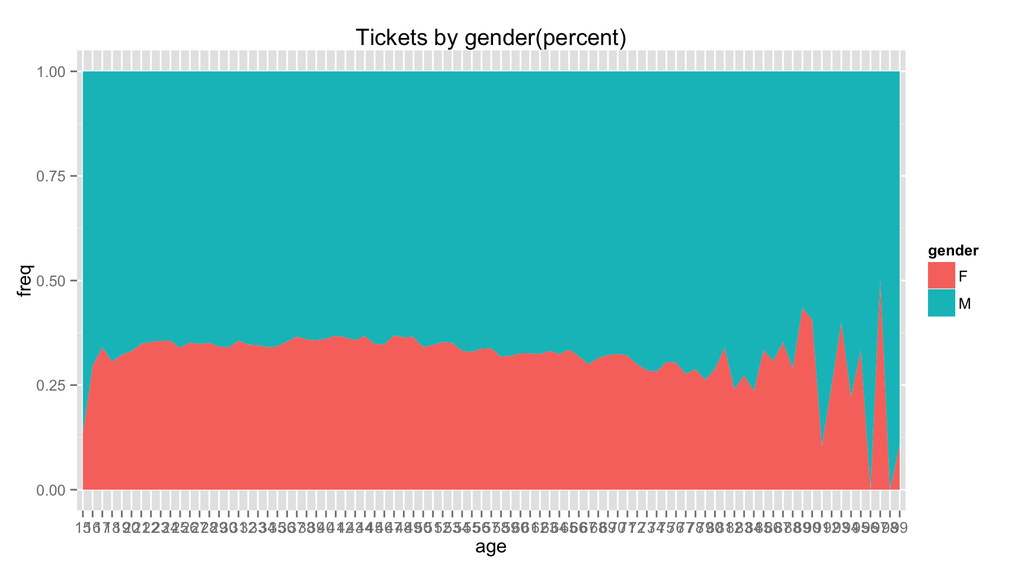

```r
tickets_gender <- data.frame(table(tickets_only$SubjectAge,tickets_only$SubjectSexCode))
colnames(tickets_gender) <- c("age", "gender", "freq")

tickets_gender_df <- tickets_gender %>% spread(gender, freq)
tickets_gender_df$perc_male <- round((tickets_gender_df$M/(tickets_gender_df$M+tickets_gender_df$F))*100, digits=2)
tickets_gender_df$perc_women <- round((tickets_gender_df$F/(tickets_gender_df$M+tickets_gender_df$F))*100, digits=2)

ggplot(tickets_gender, aes(age, freq, group=gender, fill=gender)) + ggtitle("Tickets by gender(percent)") + geom_area(position="fill")
```

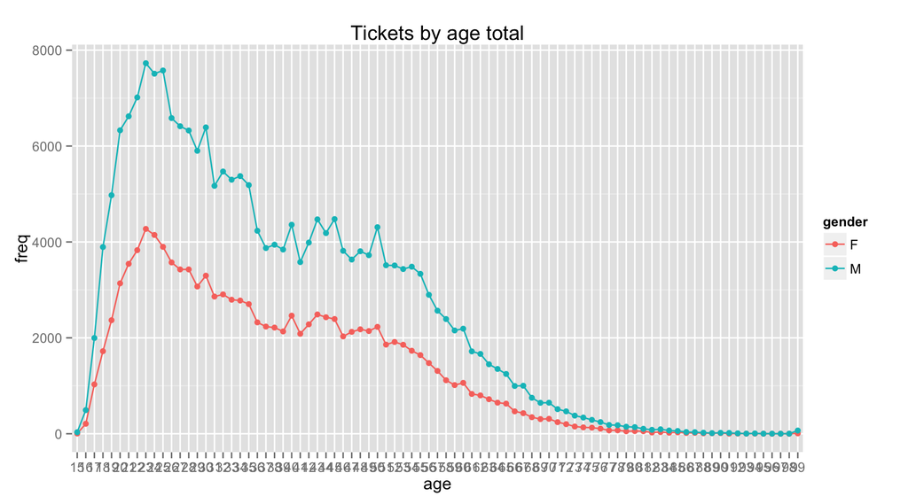

```r
ggplot(tickets_gender, aes(age, y=freq, group=gender, colour=gender)) +
  ggtitle("Tickets by age total") +
  geom_line() +
  geom_point()
```

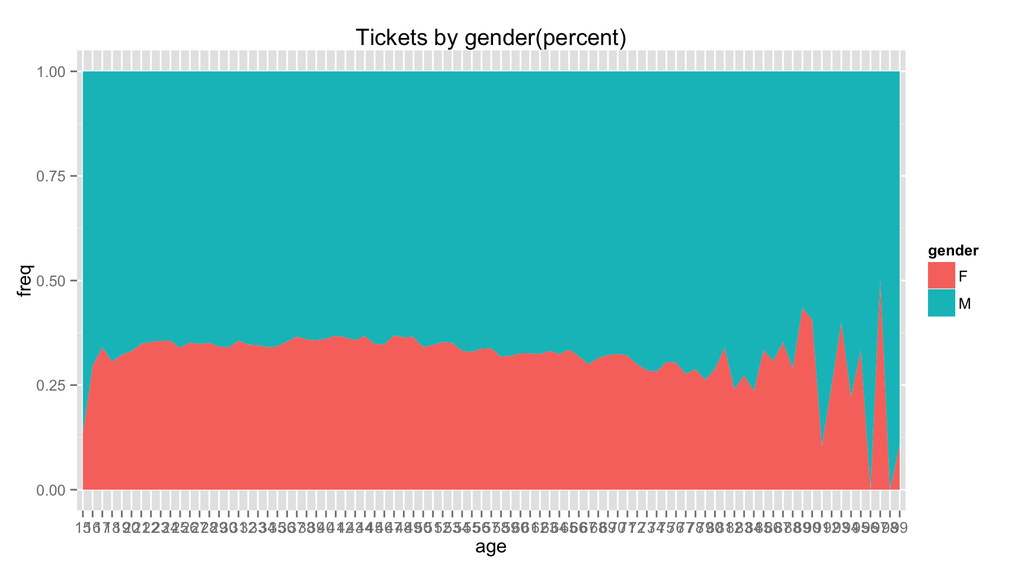

```r
tickets_gender <- data.frame(table(tickets_only$SubjectAge,tickets_only$SubjectSexCode))
colnames(tickets_gender) <- c("age", "gender", "freq")

tickets_gender_df <- tickets_gender %>% spread(gender, freq)
tickets_gender_df$perc_male <- round((tickets_gender_df$M/(tickets_gender_df$M+tickets_gender_df$F))*100, digits=2)
tickets_gender_df$perc_women <- round((tickets_gender_df$F/(tickets_gender_df$M+tickets_gender_df$F))*100, digits=2)

ggplot(tickets_gender, aes(age, freq, group=gender, fill=gender)) + ggtitle("Tickets by gender(percent)") + geom_area(position="fill")
```

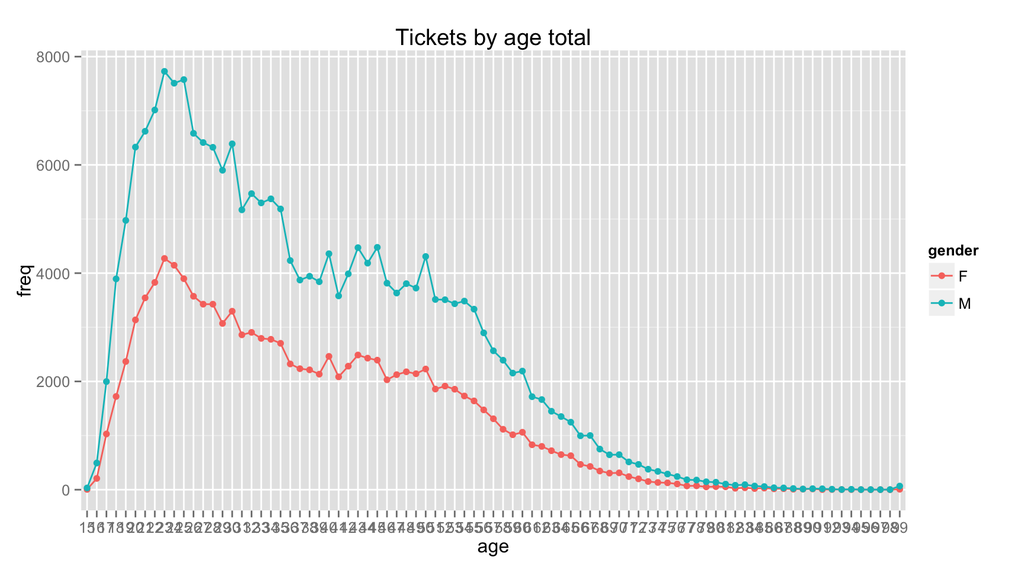

```r
ggplot(tickets_gender, aes(age, y=freq, group=gender, colour=gender)) +
  ggtitle("Tickets by age total") +
  geom_line() +
  geom_point()
```

## What about race?

```r
incidents$Race <- paste(incidents$SubjectRaceCode, incidents$SubjectEthnicityCode)

index_race <- c("A H", "A M", "A N", "B H", "B M", "B N",
           "I H", "I M", "I N", "W H", "W M", "W N")

values_race <- c("Hispanic", "Middle Eastern", "Asian", "Hispanic", "Middle Eastern", "Black",
            "Hispanic", "Middle Eastern", "Indian", "Hispanic", "Middle Eastern", "White")

incidents$Def_Race <- values_race[match(incidents$Race, index_race)]

race_df <- data.frame(table(incidents$Def_Race, incidents$What))
colnames(race_df) <- c("Race", "Type", "Freq")
race_df_spread <- race_df %>% spread(Type, Freq)
race_df_spread$perc_ticket <- round((race_df_spread$Ticket/(race_df_spread$Ticket+race_df_spread$Warning))*100, digits=2)
race_df_spread$perc_warning <- round((race_df_spread$Warning/(race_df_spread$Ticket+race_df_spread$Warning))*100, digits=2)
write.csv(race_df_spread, "race_warnings.csv")
kable(race_df_spread)
```

| Race | Ticket | Warning | perc_ticket | perc_warning |
| --- | --- | --- | --- | --- |
| Asian | 3609 | 3098 | 53.81 | 46.19 |
| Black | 44167 | 31927 | 58.04 | 41.96 |
| Hispanic | 44493 | 24884 | 64.13 | 35.87 |
| Indian | 655 | 499 | 56.76 | 43.24 |
| Middle Eastern | 22384 | 16648 | 57.35 | 42.65 |
| White | 216325 | 185910 | 53.78 | 46.22 |